# Self-Driving Car Engineer Nanodegree

## Project: **Finding Lane Lines on the Road**

In this project, you will use the tools you learned about in the lesson to identify lane lines on the road. You can develop your pipeline on a series of individual images, and later apply the result to a video stream (really just a series of images). Check out the video clip "raw-lines-example.mp4" (also contained in this repository) to see what the output should look like after using the helper functions below.

Once you have a result that looks roughly like "raw-lines-example.mp4", you'll need to get creative and try to average and/or extrapolate the line segments you've detected to map out the full extent of the lane lines. You can see an example of the result you're going for in the video "P1_example.mp4". Ultimately, you would like to draw just one line for the left side of the lane, and one for the right.

In addition to implementing code, there is a brief writeup to complete. The writeup should be completed in a separate file, which can be either a markdown file or a pdf document. There is a [write up template](https://github.com/udacity/CarND-LaneLines-P1/blob/master/writeup_template.md) that can be used to guide the writing process. Completing both the code in the Ipython notebook and the writeup template will cover all of the [rubric points](https://review.udacity.com/#!/rubrics/322/view) for this project.

Let's have a look at our first image called 'test_images/solidWhiteRight.jpg'. Run the 2 cells below (hit Shift-Enter or the "play" button above) to display the image.

**Note: If, at any point, you encounter frozen display windows or other confounding issues, you can always start again with a clean slate by going to the "Kernel" menu above and selecting "Restart & Clear Output".**

**The tools you have are color selection, region of interest selection, grayscaling, Gaussian smoothing, Canny Edge Detection and Hough Tranform line detection. You are also free to explore and try other techniques that were not presented in the lesson. Your goal is piece together a pipeline to detect the line segments in the image, then average/extrapolate them and draw them onto the image for display (as below). Once you have a working pipeline, try it out on the video stream below.**

[figure not shown]

Your output should look something like this (above) after detecting line segments using the helper functions below

[figure not shown]

Your goal is to connect/average/extrapolate line segments to get output like this

**Run the cell below to import some packages. If you get an `import error` for a package you've already installed, try changing your kernel (select the Kernel menu above --> Change Kernel). Still have problems? Try relaunching Jupyter Notebook from the terminal prompt. Also, consult the forums for more troubleshooting tips.**

## Import Packages

```python
#importing some useful packages
import matplotlib.pyplot as plt
import matplotlib.image as mpimg
import numpy as np
import cv2
%matplotlib inline
```

## Prepare a logger for debugging

```python
import logging

# create logger
logger = logging.getLogger(__name__)

#Set level to logging.DEBUG to see CRITICAL, ERROR, WARNING, INFO and DEBUG statements
#Set level to logging.ERROR to see the CRITICAL & ERROR statements only
logger.setLevel(logging.ERROR)

fileHandler = None
consoleHandler = None

if len(logger.handlers) > 0:
    for handler in logger.handlers:
        # makes sure no duplicate handlers are added
        if isinstance(handler, logging.FileHandler) and not isinstance(handler, logging.StreamHandler):
            fileHandler = handler
        elif isinstance(handler, logging.StreamHandler):
            fileHandler = handler

# create formatter
formatter = logging.Formatter('%(asctime)s - %(name)s - %(levelname)s - %(message)s')

# create file handler which logs even info messages
if fileHandler is None:
    fileHandler = logging.FileHandler('P1_info_out.log')
    fileHandler.setLevel(logging.INFO)
    fileHandler.setFormatter(formatter)
    logger.addHandler(fileHandler)

# create console handler and set level to debug
if consoleHandler is None:
    consoleHandler = logging.StreamHandler()
    consoleHandler.setLevel(logging.DEBUG)
    consoleHandler.setFormatter(formatter)
    logger.addHandler(consoleHandler)
```

## Global Variables

Global Variables used in the pipeline

```python
vertices_array = None #Used to hold the vertices accross the pipeline steps

m_list_l = None # Buffer for the mean of the left lines
c_list_l = None # Buffer for the constant of the left lines
m_list_r = None # Buffer for the mean of the right lines
c_list_r = None # Buffer for the constant of the right lines

buffer_len = 40 # The buffer size.
```

## Read in an Image

```
This image is: <class 'numpy.ndarray'> with dimensions: (540, 960, 3)
```

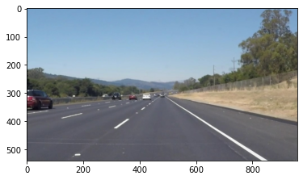

```python
#reading in an image
image = mpimg.imread('test_images/solidWhiteRight.jpg')

#printing out some stats and plotting
print('This image is:', type(image), 'with dimensions:', image.shape)
plt.imshow(image)  # if you wanted to show a single color channel image called 'gray', for example, call as plt.imshow(gray, cmap='gray')
```

## Ideas for Lane Detection Pipeline

**Some OpenCV functions (beyond those introduced in the lesson) that might be useful for this project are:**

[`cv2.inRange()`](https://docs.opencv.org/3.4/d2/de8/group__core__array.html#ga48af0ab51e36436c5d04340e036ce981) for color selection  
[`cv2.fillPoly()`](https://docs.opencv.org/3.4/d6/d6e/group__imgproc__draw.html#ga311160e71d37e3b795324d097cb3a7dc) for regions selection  
[`cv2.line()`](https://docs.opencv.org/3.4/d6/d6e/group__imgproc__draw.html#ga7078a9fae8c7e7d13d24dac2520ae4a2) to draw lines on an image given endpoints  
[`cv2.addWeighted()`](https://docs.opencv.org/3.4/d2/de8/group__core__array.html#gafafb2513349db3bcff51f54ee5592a19) to coadd / overlay two images  
`cv2.cvtColor()` to grayscale or change color  
`cv2.imwrite()` to output images to file  
[`cv2.bitwise_and()`](https://docs.opencv.org/3.4/d2/de8/group__core__array.html#ga60b4d04b251ba5eb1392c34425497e14) to apply a mask to an image

**Check out the OpenCV documentation to learn about these and discover even more awesome functionality!**

## Helper Functions

Below are some helper functions to help get you started. They should look familiar from the lesson!

```python
import math

def grayscale(img):
    """Applies the Grayscale transform
    This will return an image with only one color channel
    but NOTE: to see the returned image as grayscale
    (assuming your grayscaled image is called 'gray')
    you should call plt.imshow(gray, cmap='gray')"""
    return cv2.cvtColor(img, cv2.COLOR_RGB2GRAY)
    # Or use BGR2GRAY if you read an image with cv2.imread()
    # return cv2.cvtColor(img, cv2.COLOR_BGR2GRAY)

def canny(img, low_threshold, high_threshold):
    """Applies the Canny transform"""
    return cv2.Canny(img, low_threshold, high_threshold)

def gaussian_blur(img, kernel_size):
    """Applies a Gaussian Noise kernel"""
    return cv2.GaussianBlur(img, (kernel_size, kernel_size), 0)

def region_of_interest(img, vertices):
    """
    Applies an image mask.

    Only keeps the region of the image defined by the polygon
    formed from `vertices`. The rest of the image is set to black.
    `vertices` should be a numpy array of integer points.
    """
    #defining a blank mask to start with
    mask = np.zeros_like(img)

    #defining a 3 channel or 1 channel color to fill the mask with depending on the input image
    if len(img.shape) > 2:
        channel_count = img.shape[2]  # i.e. 3 or 4 depending on your image
        ignore_mask_color = (255,) * channel_count
    else:
        ignore_mask_color = 255

    #filling pixels inside the polygon defined by "vertices" with the fill color
    cv2.fillPoly(mask, vertices, ignore_mask_color)

    #returning the image only where mask pixels are nonzero
    masked_image = cv2.bitwise_and(img, mask)
    return masked_image


def draw_lines(img, lines, color=[255, 255, 0], thickness=2):
    """
    NOTE: this is the function you might want to use as a starting point once you want to
    average/extrapolate the line segments you detect to map out the full
    extent of the lane (going from the result shown in raw-lines-example.mp4
    to that shown in P1_example.mp4).

    Think about things like separating line segments by their
    slope ((y2-y1)/(x2-x1)) to decide which segments are part of the left
    line vs. the right line.  Then, you can average the position of each of
    the lines and extrapolate to the top and bottom of the lane.

    This function draws `lines` with `color` and `thickness`.
    Lines are drawn on the image inplace (mutates the image).
    If you want to make the lines semi-transparent, think about combining
    this function with the weighted_img() function below
    """
    for line in lines:
        for x1,y1,x2,y2 in line:
            cv2.line(img, (x1, y1), (x2, y2), color, thickness)

def hough_lines(img, rho, theta, threshold, min_line_len, max_line_gap):
    """
    `img` should be the output of a Canny transform.

    Returns an image with hough lines drawn.
    """
    lines = cv2.HoughLinesP(img, rho, theta, threshold, np.array([]), minLineLength=min_line_len, maxLineGap=max_line_gap)
    line_img = np.zeros((img.shape[0], img.shape[1], 3), dtype=np.uint8)
#     if logging.DEBUG >= logger.level:
    draw_lines(line_img, lines)
    draw_lane (line_img, lines)
    return line_img

# Python 3 has support for cool math symbols.

def weighted_img(img, initial_img, α=0.9, β=1., γ=0.):
    """
    `img` is the output of the hough_lines(), An image with lines drawn on it.
    Should be a blank image (all black) with lines drawn on it.

    `initial_img` should be the image before any processing.

    The result image is computed as follows:

    initial_img * α + img * β + γ
    NOTE: initial_img and img must be the same shape!
    """
    return cv2.addWeighted(initial_img, α, img, β, γ)
```

#### Identify Mask Region

The region is as of polygon of 4 vertices. To calculate it in reference to the original image, I used the below diagram to explain it.

[figure not shown]

```python
def vertices(img, x_up = 0.06, x_bottom = 0.42, y_up=0.39, y_bottom = 0):
    """
    the Input ranges are percentage of xsize and ysize of the image
    """
    ysize = img.shape[0]
    xsize = img.shape[1]

    xBottom = int(x_bottom * xsize)
    xUp = int(x_up * xsize)
    yBottom = int(y_bottom * ysize)
    yUp = int(y_up * ysize)

    # The returned vertics for the following points in order:
    # B, A, D, and C
    return np.array([[(xsize/2 - xBottom, ysize-yBottom), \
        (xsize/2 - xUp, ysize - yUp), \
        (xsize/2 + xUp, ysize - yUp), \
        (xsize/2 + xBottom, ysize-yBottom)]], dtype=np.int32)
```

## Draw Lane boundries

This is the enhanced version of draw_lines in which we extrapolate the line from the line segments identified in Hough Transformation.

To do so we first draw the lines of the left edge of the lane and its lane line indicator then we do the same for the right edge.

To identify to lane line we use the segments of the lines and pass it to the interpolate the line out of these segments. If we are doing this for a video we will keep a buffer for the last 40 lines calculated within the range and get the mean of it to get the best value of it.

We start first with the `get_line` method to get the line out of the given small lines.

### `get_line` to extrapolate a line.

This method is to extrapolate the line out of the given small lines. We need to identify first if this is the right or left line (in the left side of the image or right side of the image) and if it is within the given region

```python
def get_line (img, lines, left_line = True):
    """
    NOTE: this function is used to extrapolate the line from the given lines.
    """
    x_points = [] # x_points[0] will present the left line while x_points[1] is the right line
    y_points = [] # y_points[0] will present the left line while y_points[1] is the right line
    x_points.append([])
    y_points.append([])

    ysize = img.shape[0]
    xsize = img.shape[1]

    if lines is not None:
        for line in lines:
            for x1,y1,x2,y2 in line:
                try:
                    slop = (y2-y1)/(x2-x1)
                    if left_line and slop < 0 and x1 < xsize/2 and x2 < xsize/2: # -ve slop is left line and where y > x
                        x_points[0].append (x1)
                        x_points[0].append (x2)
                        y_points[0].append (y1)
                        y_points[0].append (y2)
                    elif not left_line and slop >= 0 and x1 >= xsize/2 and x2 >= xsize/2: # +ve slop is right line and where y > x
                        x_points[0].append (x1)
                        x_points[0].append (x2)
                        y_points[0].append (y1)
                        y_points[0].append (y2)
                except:
                    logger.debug ("invalid slop, x1, y1: %s, %s - x2, y2: %s, %s", x1, y1, x2, y2)

    # Identify left line
    line = None
    global m_list_l, c_list_l, m_list_r, c_list_r


    if left_line:
        m_list = m_list_l
        c_list = c_list_l
    else:
        m_list = m_list_r
        c_list = c_list_r

    logger.debug('The region vertices is: %s ',vertices_array)
    x_bottom_l, y_bottom = vertices_array [0][0] # Point B in the vertices
    x_up_l, y_up = vertices_array [0][1] # Point A
    x_up_r = vertices_array [0][2][0] # Point D
    x_bottom_r = vertices_array [0][3][0] # Point C

    x = np.array(x_points[0])
    y = np.array(y_points[0])

    # y_bottom = ysize -1
    # y_up = min(y)

    m, c = None, None

    if len(x) > 0 and len (y) > 0:
        line_fit = np.polyfit(x, y, 1)

        # y = mx + c
        # x = (y - c)/m
        # So we get x at the point in the image = y_bottom & y_up to draw complete lines
        m, c = line_fit

        in_range = False
        x1 = int((y_bottom -c)/m)
        x2 = int((y_up -c)/m)

        if x1 >= x_bottom_l and x1 <= x_bottom_r and x2 >= x_up_l and x2 <= x_up_r:
            in_range = True

        if in_range:
            # Save both m an c in a buffer
            m_list = np.insert(m_list, 0, m)
            c_list = np.insert(c_list, 0, c)

            # Keep only the last [buffer_len] elements in the buffer and delete the older elements.
            if len(m_list) > buffer_len:
                m_list = np.delete(m_list, -1)
                c_list = np.delete(c_list, -1)

            # get the avarage of the list as the new value of m & c
            m = np.mean(m_list)
            c = np.mean(c_list)

            if left_line: # Keep the updated arrays
                m_list_l = m_list
                c_list_l = c_list
            else:
                m_list_r = m_list
                c_list_r = c_list

        elif len(m_list) > 0: # ignore the values of this line and use the last values
            m = np.mean(m_list)
            c = np.mean(c_list)

        if m is not None:
            line = np.array([int((y_bottom -c)/m), y_bottom, int((y_up -c)/m), y_up])

    # even if there is no lines, get the latest mean values from buffer
    elif len(m_list) > 0:
        m = np.mean(m_list)
        c = np.mean(c_list)
        line = np.array([int((y_bottom -c)/m), y_bottom, int((y_up -c)/m), y_up])

    if line is None:
        logger.debug ("No line for input lines: %s and left_line is: %s", lines, left_line)

    return line
```

### `draw_lane` to draw lane boundries

In this method, we use the `get_line` method to draw two lines for the left and right boundries of the lane.

```python
def draw_lane(img, lines, color=[255, 0, 0], thickness=9):
    """
    NOTE: this is the function you might want to use as a starting point once you want to
    average/extrapolate the line segments you detect to map out the full
    extent of the lane (going from the result shown in raw-lines-example.mp4
    to that shown in P1_example.mp4).

    Think about things like separating line segments by their
    slope ((y2-y1)/(x2-x1)) to decide which segments are part of the left
    line vs. the right line.  Then, you can average the position of each of
    the lines and extrapolate to the top and bottom of the lane.

    This function draws `lines` with `color` and `thickness`.
    Lines are drawn on the image inplace (mutates the image).
    If you want to make the lines semi-transparent, think about combining
    this function with the weighted_img() function below
    """
    lane_lines = np.empty([0, 1, 4], dtype=int)
    left_line = get_line (img, lines, left_line = True)

    if left_line is not None:
        lane_lines = np.append (lane_lines, [[left_line]], axis=0)

    right_line = get_line (img, lines, left_line = False)
    if right_line is not None:
        lane_lines = np.append (lane_lines, [[right_line]], axis=0)


    #logger.debug('lane lines are : %s', lane_lines)

    draw_lines (img, lane_lines, color, thickness)
```

## Test Images

Build your pipeline to work on the images in the directory "test_images"  
**You should make sure your pipeline works well on these images before you try the videos.**

```python
import os
images_list = os.listdir("test_images/")
logger.debug('Images list is: %s', images_list)
```

### Build a Lane Finding Pipeline

Build the pipeline and run your solution on all test_images. Make copies into the `test_images_output` directory, and you can use the images in your writeup report.

Try tuning the various parameters, especially the low and high Canny thresholds as well as the Hough lines parameters.

#### Build the pipeline

I built the pipeline with the folllowing steps:

1. Get the gray scale of the original image and then apply the Gussian Bluring methof on the gray image wich is the outocme of step 1.
2. Apply Canny method to identify edges in image on outcome of step 2.
3. Identify region of intrest using the `vertices()` with the identification of x_up, x_bottom, y_up, y_bottom as per the diagram shown in the *Identify Region Mask* step. Apply the mask on the outcome of step 3
4. Apply Hough Transformation on the outcome of step 4 to be able to identify the lines in the image.
5. Mix the identified lane image in step 5 with the original image to show the lanes on it.

```python
# TODO: Build your pipeline that will draw lane lines on the test_images
# then save them to the test_images_output directory.
def find_lanes (img, config):
    """
    `img` should be the image to find the lanes and mark them in it..

    Returns the original image with lanes marked.
    """

    #Step 1. Get the gray scale of the original image and apply bluring
    initial_img = img
    gray_image = grayscale (initial_img)

    kernel_size = config.get('kernel_size', 7) #default value is 7

    logger.info('Kernel_size tested at: %s ',kernel_size)
    blur_gray_image = gaussian_blur (gray_image, kernel_size)

    #Step 2. Apply Canny method to identify edges in image.
    # Parameters tuned using the OpenCV-GUI-Helper-Tool
    low_threshold = config.get('low_threshold', 58)
    high_threshold = config.get('high_threshold', 136)
    logger.info('Canny parameters: low_threshold tested at: %s - high_threshold tested at: %s ',low_threshold, high_threshold)
    edges_image = canny(blur_gray_image, low_threshold, high_threshold)

    #Step 3. Identify region of intrest.
    # Identify a region of 4 points for interest.
    x_up = config.get('x_up', 0.06)
    x_bottom = config.get('x_bottom', 0.42)
    y_up = config.get('y_up', 0.37)
    y_bottom = config.get('y_bottom', 0.02)

    global vertices_array

    vertices_array = vertices (img,  x_up, x_bottom, y_up, y_bottom)
    logger.info('The masked region vertices of the image is: %s ',vertices_array)
    masked_edges = region_of_interest(edges_image, vertices_array)

    #Step 4. Apply Hough Transformation on the image to be able to identify the lines in the image.
    # I went through different trials .. for list of trials please refer to P1_info_out.log
    # Then I used the parameters from my parameters tuner tool.
    rho = config.get('rho', 2) # distance resolution in pixels of the Hough grid
    theta = config.get('theta', np.pi/180)  # angular resolution in radians of the Hough grid
    threshold = config.get('threshold', 7)     # minimum number of votes (intersections in Hough grid cell)
    min_line_length = config.get('min_line_length', 4) #minimum number of pixels making up a line
    max_line_gap = config.get('max_line_gap', 9)    # maximum gap in pixels between connectable line segments
    logger.info('The Hough parameters used are: rho=%s, theta=%s, threshold=%s, min_line_length=%s, max_line_gap=%s', \
                rho, theta, threshold, min_line_length, max_line_gap)
    lines_edges = hough_lines(masked_edges, rho, theta, threshold, min_line_length, max_line_gap)

    #Step 5: mix the identified lane image with the original image to show the lanes on it.
    lines_image = weighted_img(lines_edges, initial_img)

    return lines_image
```

## Test on Images

### Execute the pipeline.

I configured the pipeline with the following parameters to work with the images.

> I have to reset the buffer that I created in the image case so I don't take the history of other images.

I used [my OpenCV GUI Pipeline tuner](https://github.com/abou7abiba/opencv-gui-pipline-tuner.git) to identify the best configuratin which is summerized in the following settings:

[output not shown]

```python
for img_file_name in images_list:
    #reading in an image
    in_file_path = os.path.join("test_images", img_file_name)
    image = mpimg.imread(in_file_path)
    #image = cv2.imread(in_file_path)

    global m_list_l, c_list_l, m_list_r, c_list_r

    #Reset buffers for tracking lane line paramters.
    m_list_l = np.zeros(0) # Buffer for the mean of the left lines
    c_list_l = np.zeros(0) # Buffer for the constant of the left lines
    m_list_r = np.zeros(0) # Buffer for the mean of the right lines
    c_list_r = np.zeros(0) # Buffer for the constant of the right lines

    logger.info('Open Image: %s is: %s with dimensions: %s', in_file_path, type(image), image.shape)

    config = {'kernel_size': 9, 'low_threshold': 58, 'high_threshold': 136, \
              'x_up' : 0.06, 'x_bottom' : 0.42, 'y_up' : 0.37, 'y_bottom' : 0.02, \
             'rho' : 2, 'theta' : np.pi/180, 'threshold' : 7, 'min_line_length' : 4, 'max_line_gap' : 9}

    # Apply pipeline.
    marked_image = find_lanes (image, config)

    #Fix the colors
    r, g, b = cv2.split (marked_image)
    marked_image = cv2.merge ((b, g, r))

    # Save image file.
    (head, tail) = os.path.split(img_file_name)
    (root, ext) = os.path.splitext(tail)
    out_file_path = os.path.join("test_images_output", root + "-marked" + ext)
    logger.info('Save marked image at %s', out_file_path)

    cv2.imwrite(out_file_path, marked_image)
```

## Test on Videos

You know what's cooler than drawing lanes over images? Drawing lanes over video!

We can test our solution on two provided videos:

`solidWhiteRight.mp4`

`solidYellowLeft.mp4`

**Note: if you get an import error when you run the next cell, try changing your kernel (select the Kernel menu above --> Change Kernel). Still have problems? Try relaunching Jupyter Notebook from the terminal prompt. Also, consult the forums for more troubleshooting tips.**

**If you get an error that looks like this:**

```
NeedDownloadError: Need ffmpeg exe.
You can download it by calling:
imageio.plugins.ffmpeg.download()
```

**Follow the instructions in the error message and check out [this forum post](https://discussions.udacity.com/t/project-error-of-test-on-videos/274082) for more troubleshooting tips across operating systems.**

```python
# Import everything needed to edit/save/watch video clips
from moviepy.editor import VideoFileClip
from IPython.display import HTML
```

For the test videos, I used the following settings

[output not shown]

```python
def process_image(image):
    # NOTE: The output you return should be a color image (3 channel) for processing video below
    # TODO: put your pipeline here,
    # you should return the final output (image where lines are drawn on lanes)

    config = {'kernel_size': 13, 'low_threshold': 37, 'high_threshold': 94, \
              'x_up' : 0.09, 'x_bottom' : 0.42, 'y_up' : 0.36, 'y_bottom' : 0.0, \
             'rho' : 2, 'theta' : np.pi/180, 'threshold' : 7, 'min_line_length' : 4, 'max_line_gap' : 9}

    return find_lanes (image, config)
```

Let's try the one with the solid white lane on the right first ...

```python
white_output = 'test_videos_output/solidWhiteRight.mp4'
## To speed up the testing process you may want to try your pipeline on a shorter subclip of the video
## To do so add .subclip(start_second,end_second) to the end of the line below
## Where start_second and end_second are integer values representing the start and end of the subclip
## You may also uncomment the following line for a subclip of the first 5 seconds
##clip1 = VideoFileClip("test_videos/solidWhiteRight.mp4").subclip(0,5)

#Reset buffers for tracking lane line paramters.
m_list_l = np.zeros(0) # Buffer for the mean of the left lines
c_list_l = np.zeros(0) # Buffer for the constant of the left lines
m_list_r = np.zeros(0) # Buffer for the mean of the right lines
c_list_r = np.zeros(0) # Buffer for the constant of the right lines

clip1 = VideoFileClip("test_videos/solidWhiteRight.mp4")
white_clip = clip1.fl_image(process_image) #NOTE: this function expects color images!!
%time white_clip.write_videofile(white_output, audio=False)
```

```
Moviepy - Building video test_videos_output/solidWhiteRight.mp4.
Moviepy - Writing video test_videos_output/solidWhiteRight.mp4
```

```
Moviepy - Done !
Moviepy - video ready test_videos_output/solidWhiteRight.mp4
Wall time: 2.73 s
```

Play the video inline, or if you prefer find the video in your filesystem (should be in the same directory) and play it in your video player of choice.

```python
HTML("""
<video width="960" height="540" controls>
  <source src="{0}">
</video>
""".format(white_output))
```

[video not shown]

## Improve the draw_lines() function

**At this point, if you were successful with making the pipeline and tuning parameters, you probably have the Hough line segments drawn onto the road, but what about identifying the full extent of the lane and marking it clearly as in the example video (P1_example.mp4)? Think about defining a line to run the full length of the visible lane based on the line segments you identified with the Hough Transform. As mentioned previously, try to average and/or extrapolate the line segments you've detected to map out the full extent of the lane lines. You can see an example of the result you're going for in the video "P1_example.mp4".**

**Go back and modify your draw_lines function accordingly and try re-running your pipeline. The new output should draw a single, solid line over the left lane line and a single, solid line over the right lane line. The lines should start from the bottom of the image and extend out to the top of the region of interest.**

Now for the one with the solid yellow lane on the left. This one's more tricky!

```python
yellow_output = 'test_videos_output/solidYellowLeft.mp4'
## To speed up the testing process you may want to try your pipeline on a shorter subclip of the video
## To do so add .subclip(start_second,end_second) to the end of the line below
## Where start_second and end_second are integer values representing the start and end of the subclip
## You may also uncomment the following line for a subclip of the first 5 seconds
##clip2 = VideoFileClip('test_videos/solidYellowLeft.mp4').subclip(0,5)

#Reset buffers for tracking lane line paramters.
m_list_l = np.zeros(0) # Buffer for the mean of the left lines
c_list_l = np.zeros(0) # Buffer for the constant of the left lines
m_list_r = np.zeros(0) # Buffer for the mean of the right lines
c_list_r = np.zeros(0) # Buffer for the constant of the right lines

clip2 = VideoFileClip('test_videos/solidYellowLeft.mp4')
yellow_clip = clip2.fl_image(process_image)
%time yellow_clip.write_videofile(yellow_output, audio=False)
```

```
Moviepy - Building video test_videos_output/solidYellowLeft.mp4.
Moviepy - Writing video test_videos_output/solidYellowLeft.mp4
```

```
Moviepy - Done !
Moviepy - video ready test_videos_output/solidYellowLeft.mp4
Wall time: 6.68 s
```

```python
HTML("""
<video width="960" height="540" controls>
  <source src="{0}">
</video>
""".format(yellow_output))
```

[video not shown]

## Writeup and Submission

If you're satisfied with your video outputs, it's time to make the report writeup in a pdf or markdown file. Once you have this Ipython notebook ready along with the writeup, it's time to submit for review! Here is a [link](https://github.com/udacity/CarND-LaneLines-P1/blob/master/writeup_template.md) to the writeup template file.

## Optional Challenge

Try your lane finding pipeline on the video below. Does it still work? Can you figure out a way to make it more robust? If you're up for the challenge, modify your pipeline so it works with this video and submit it along with the rest of your project!

```python
def process_challenge_image(image):
    # NOTE: The output you return should be a color image (3 channel) for processing video below
    # TODO: put your pipeline here,
    # you should return the final output (image where lines are drawn on lanes)

    config = {'kernel_size': 13, 'low_threshold': 52, 'high_threshold': 77, \
              'x_up' : 0.14, 'x_bottom' : 0.42, 'y_up' : 0.33, 'y_bottom' : 0.08, \
             'rho' : 2, 'theta' : np.pi/180, 'threshold' : 26, 'min_line_length' : 1, 'max_line_gap' : 12}

    return find_lanes (image, config)
```

```python
challenge_output = 'test_videos_output/challenge.mp4'
## To speed up the testing process you may want to try your pipeline on a shorter subclip of the video
## To do so add .subclip(start_second,end_second) to the end of the line below
## Where start_second and end_second are integer values representing the start and end of the subclip
## You may also uncomment the following line for a subclip of the first 5 seconds
##clip3 = VideoFileClip('test_videos/challenge.mp4').subclip(0,5)
clip3 = VideoFileClip('test_videos/challenge.mp4')
challenge_clip = clip3.fl_image(process_challenge_image)
%time challenge_clip.write_videofile(challenge_output, audio=False)
```

```
Moviepy - Building video test_videos_output/challenge.mp4.
Moviepy - Writing video test_videos_output/challenge.mp4
```

```
Moviepy - Done !
Moviepy - video ready test_videos_output/challenge.mp4
Wall time: 4.62 s
```

```python
HTML("""
<video width="960" height="540" controls>
  <source src="{0}">
</video>
""".format(challenge_output))
```

[video not shown]